# Project Assignment

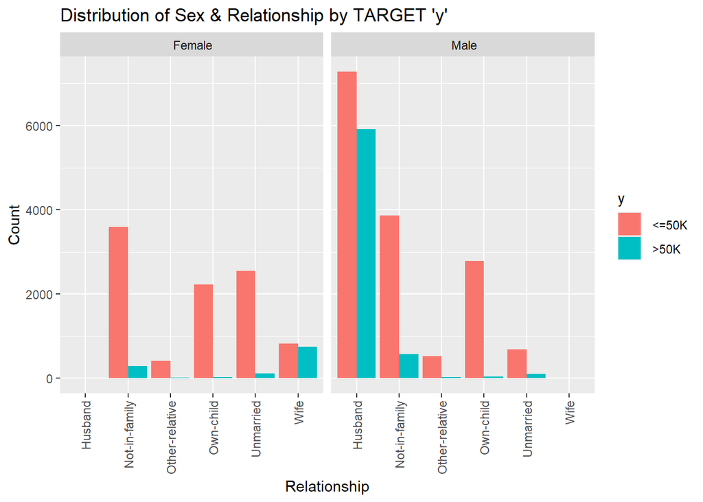

```r
# Bar Chart between Sex & Relationship by TARGET 'y'

census %>%
  ggplot(mapping = aes(x = relationship, fill = y)) +
  geom_bar(position = "dodge") +
  facet_wrap(~ sex) +
  labs(title = "Distribution of Sex & Relationship by TARGET 'y'",
       x = "Relationship",
       y = "Count",
       fill = "y") +
  theme(axis.text.x = element_text(angle = 90, vjust = 0.5, hjust = 1),
        axis.text.y = element_text(angle = 0))
```

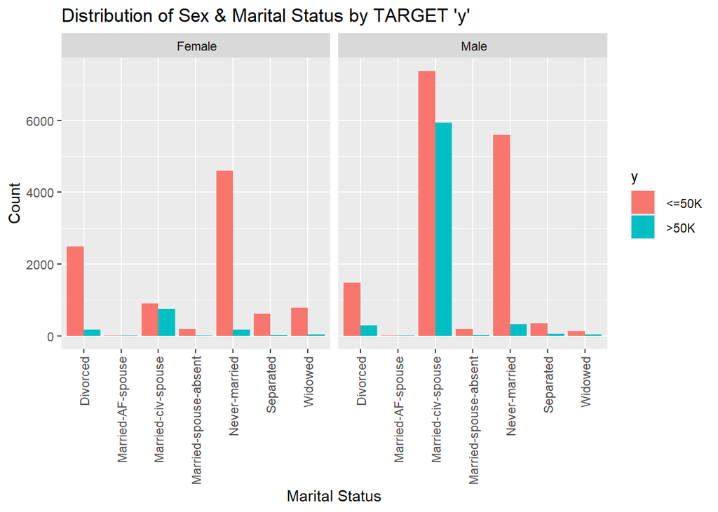

```r
# Bar Chart between Sex & Marital Status by TARGET 'y'

census %>%
  ggplot(mapping = aes(x = marital.status, fill = y)) +
  geom_bar(position = "dodge") +
  facet_wrap(~ sex) +
  labs(title = "Distribution of Sex & Marital Status by TARGET 'y'",
       x = "Marital Status",
       y = "Count",
       fill = "y") +
  theme(axis.text.x = element_text(angle = 90, vjust = 0.5, hjust = 1),
        axis.text.y = element_text(angle = 0))
```

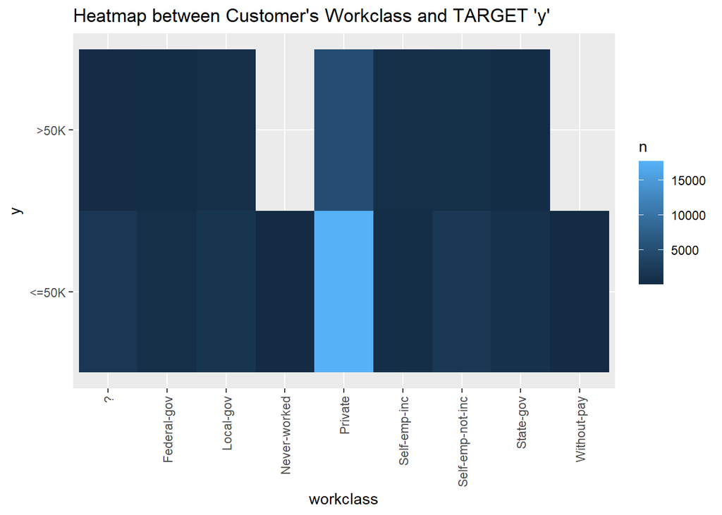

```r
# Heatmap between workclass and TARGET 'y'

census %>%
  group_by(workclass, y) %>%
  summarise(n = n()) %>%
  ggplot(aes(x = workclass, y = y)) +
  geom_tile(aes(fill = n)) +
  theme(axis.text.x = element_text(angle = 90, vjust = 0.5, hjust = 1),
        axis.text.y = element_text(angle = 0)) +
  labs(title = "Heatmap between Customer's Workclass and TARGET 'y'")
```

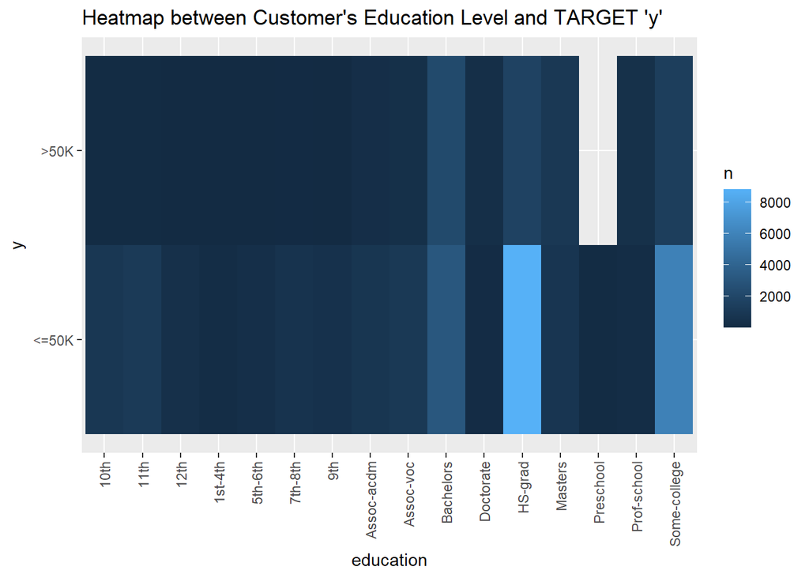

```r
# Heatmap between education and TARGET 'y'

census %>%
  group_by(education, y) %>%
  summarise(n = n()) %>%
  ggplot(aes(x = education, y = y)) +
  geom_tile(aes(fill = n)) +
  theme(axis.text.x = element_text(angle = 90, vjust = 0.5, hjust = 1),
        axis.text.y = element_text(angle = 0)) +
  labs(title = "Heatmap between Customer's Education Level and TARGET 'y'")
```

## 2.5 List of all Supervised Models

1. Decision Trees using C5.0(),
2. Naïve Bayes Model,
3. Linear Regression,
4. Decision Tree (rpart),
5. M5P (A model similar to decision trees),
6. Neural Network Models (make_Weka_classifier()),
7. Support Vector Machine (ksvm()),
8. KNN (IBk) Model,
9. SimpleKMeans(), and
10. Apriori()

For this project we have a categorical target variable i.e. a classification task with supervised learning. Out of this list above the models Linear Regression, M5P, SimpleKMeans(), and Apriori() are not suitable for classification tasks with a categorical target variable. Linear Regression and M5P are regression algorithms, SimpleKMeans() is used for clustering, and Apriori() is used for association rule mining. Therefore, the list can be narrowed down to:

1. Decision Trees using C5.0(),
2. Naïve Bayes Model,
3. Decision Tree (rpart),
4. Neural Network Models (make_Weka_classifier()),
5. Support Vector Machine (ksvm()), and
6. KNN (IBk) Model.

# 3 Data Preperation

## 3.1 Spliting Dataset into Training and Testing Sets

This code prepares and partitions the census dataset for training and testing machine learning models. It begins by setting the seed for reproducibility and creating a 70-30 split, with 70% of the data allocated for the training set and 30% for the test set. The lengths and classes of the training set indexes are checked, then the dataset is split accordingly. The number of rows in both sets is displayed. Tables are generated to show the proportions of “yes” and “no” values in the target variable y for both the training and test sets. The code also checks for any missing values in both datasets. Finally, it prepares to generate multiple prediction evaluation metrics such as accuracy, precision, true positive rate, and F1 score using the rminer package.

```r
set.seed(100)  #Creating data partition by using 70% of data for the training set and 30% for the test set
census_train <- createDataPartition(census$y, p=0.7, list=FALSE)

length(census_train)
```

```
## [1] 22793
```

```r
class(census_train)
```

```
## [1] "matrix" "array"
```

```r
train_set <- census[census_train,]  #spliting the dataset using the indexes
test_set <- census[-census_train,]

train_set %>% nrow()  #Showing number of rows in both train and test sets
```

```
## [1] 22793
```

```r
test_set %>% nrow()
```

```
## [1] 9768
```

```r
train_set %>% select(y) %>% table() #Showing the proportion of yes and no in y for training set
```

```
## y
##  <=50K   >50K
##  17304   5489
```

```r
train_set %>% select(y) %>% table() %>% prop.table() %>% round(2) * 100
```

```
## y
##  <=50K   >50K
##     76     24
```

```r
test_set %>% select(y) %>% table() #Showing the proportion of yes and no in y for training set
```

```
## y
##  <=50K   >50K
##   7416   2352
```

```r
test_set %>% select(y) %>% table() %>% prop.table() %>% round(2) * 100
```

```
## y
##  <=50K   >50K
##     76     24
```

```r
# Generating multiple prediction evaluation metrics using rminer package

metrics_list <- c("ACC","PRECISION","TPR","F1")

# Checking for NA Values in the train and test datasets

any(is.na(train_set))
```

```
## [1] FALSE
```

```r
any(is.na(test_set))
```

```
## [1] FALSE
```

## 3.2 Cross-validation function for numeric prediction models

```r
cv_function <- function(df, target, nFolds, seedVal, classification, metrics_list)
{
  set.seed(seedVal)
  folds = createFolds(df[,target],nFolds)

  cv_results <- lapply(folds, function(x)
{
  test_target <- df[x,target]
  test_input <- df[x,-target]

  train_target <- df[-x,target]
  train_input <- df[-x,-target]

  pred_model <- prediction_method(train_target~.,train_input)

  pred <- predict(pred_model, test_input)
# return saves performance results in cv_results[[i]]
  return(mmetric(test_target,pred,metrics_list))
})

  cv_results_m <- as.matrix(as.data.frame(cv_results))

  cv_mean<- as.matrix(rowMeans(cv_results_m))

  colnames(cv_mean) <- "Mean"

  cv_sd <- as.matrix(rowSds(cv_results_m))

  colnames(cv_sd) <- "Sd"

  cv_all <- cbind(cv_results_m, cv_mean, cv_sd)

  kable(cv_all,digits=2)
}
```

# 4 Model Building

## 4.1 Simple Model Training and Testing for all selected models

This code chunk trains and evaluates multiple machine learning models including Decision Trees (C5.0 and rpart), Naive Bayes, Multilayer Perceptron (NNM), Support Vector Machine (SVM), and k-Nearest Neighbors (KNN) on the prepared training and testing datasets. Each model’s performance is evaluated using multiple metrics such as accuracy, precision, true positive rate, and F1 score. The code provides insight into how these models perform on both the training and test datasets, aiming to find the best-performing model for the given data.

```r
# Using the train set to train a C5.0 model

C5.0_model <- C5.0(formula = y ~ .,data = train_set, control = C5.0Control(CF = 0.005, earlyStopping = FALSE, noGlobalPruning = FALSE)) # Creating decision tree for CF = 0.005 for interpretability purposes and to get a balance between overfitting and underfitting.
C5.0_model
```

```
##
## Call:
## C5.0.formula(formula = y ~ ., data = train_set, control = C5.0Control(CF
##  = 0.005, earlyStopping = FALSE, noGlobalPruning = FALSE))
##
## Classification Tree
## Number of samples: 22793
## Number of predictors: 14
##
## Tree size: 20
##
## Non-standard options: attempt to group attributes, confidence level: 0.005
```

```r
# Generating prediction for the C5.0 model for both the train and test set

C5.0_model_train_predictions <- predict(C5.0_model,train_set)
C5.0_model_test_predictions <- predict(C5.0_model,test_set)

# Creating confusion matrix for both the train and test set data

Confusion_Matrix_train_1 <- table(predicted = C5.0_model_train_predictions,
                                  observed = train_set$y)
Confusion_Matrix_train_1
```

```
##          observed
## predicted  <=50K  >50K
##     <=50K  16741  2556
##     >50K     563  2933
```

```r
Confusion_Matrix_test_1 <- table(predicted = C5.0_model_test_predictions,
                                  observed = test_set$y)
Confusion_Matrix_test_1
```

```
##          observed
## predicted  <=50K  >50K
##     <=50K   7134  1126
##     >50K     282  1226
```

```r
# Checking for different metrics of how the model performed on both the train and test datasets

mmetric(train_set$y, C5.0_model_train_predictions, metric= metrics_list)
```

```
##        ACC PRECISION1 PRECISION2       TPR1       TPR2        F11        F12
##   86.31597   86.75442   83.89588   96.74642   53.43414   91.47837   65.28659
```

```r
mmetric(test_set$y, C5.0_model_test_predictions, metric = metrics_list)
```

```
##        ACC PRECISION1 PRECISION2       TPR1       TPR2        F11        F12
##   85.58559   86.36804   81.29973   96.19741   52.12585   91.01812   63.52332
```

```r
# Using the C5imp() function to see the least important predictors from the decision tree model

C5imp(C5.0_model)
```

```
##                Overall
## capital.gain    100.00
## relationship     95.06
## capital.loss     95.06
## education.num    39.01
## hours.per.week    9.96
## age               9.11
## occupation        8.80
## marital.status    0.51
## workclass         0.00
## fnlwgt            0.00
## education         0.00
## race              0.00
## sex               0.00
## native.country    0.00
```

```r
# Creating a simple Naive Bayes Model from the training set

naive_model <- naiveBayes(y ~ ., data = train_set)
naive_model
```

[output not shown]

[output cut: 98 more lines]

[output not shown]

```r
summary(naive_model)
```

```
##           Length Class  Mode
## apriori    2     table  numeric
## tables    14     -none- list
## levels     2     -none- character
## isnumeric 14     -none- logical
## call       4     -none- call
```

```r
# Generating prediction for the simple naive bayes model for both the train and test set

naive_model_train_predictions <- predict(naive_model,train_set)
naive_model_test_predictions <- predict(naive_model,test_set)

# Creating confusion matrix for both the train and test set data

Confusion_Matrix_train_2 <- table(predicted = naive_model_train_predictions,
                                  observed = train_set$y)
Confusion_Matrix_train_2
```

```
##          observed
## predicted  <=50K  >50K
##     <=50K  16164  2764
##     >50K    1140  2725
```

```r
Confusion_Matrix_test_2 <- table(predicted = naive_model_test_predictions,
                                  observed = test_set$y)
Confusion_Matrix_test_2
```

```
##          observed
## predicted  <=50K  >50K
##     <=50K   6889  1184
##     >50K     527  1168
```

```r
# Checking for accuracy of how the model performed on both the train and test datasets

mmetric(train_set$y, naive_model_train_predictions, metric= metrics_list)
```

```
##        ACC PRECISION1 PRECISION2       TPR1       TPR2        F11        F12
##   82.87193   85.39730   70.50453   93.41193   49.64474   89.22499   58.26384
```

```r
mmetric(test_set$y, naive_model_test_predictions, metric = metrics_list)
```

```
##        ACC PRECISION1 PRECISION2       TPR1       TPR2        F11        F12
##   82.48362   85.33383   68.90855   92.89374   49.65986   88.95345   57.72177
```